# Item Analysis, EFA, and CFA

Florian Brühlmann

April 16, 2018

# Overview and goals

After creating a pool of questionnaire items, and possibly reduce the pool employing an expert review and an item sort task, this pool is administered to a development sample. In some cases, other construct-related questionnaires are included to decide which items to retain and which to remove. Part of these methods is usually some sort of item analysis and an exploratory factor analysis. Depending on the context or goal of the questionnaire, different methods might be appropriate. This example here will cover the following:

1. Data cleaning
2. Descriptive analysis
3. Item analysis
4. Exploratory factor analysis
5. Confirmatory factor analysis

Packages used in this example:

```r
library(psych)
```

# Description of the dataset

## Load in data

```r
data <- read.csv(url("https://bruehlmann.io/projects/umi/data/umi_data.csv"))
```

If you have exported the data as a csv directly from unipark:

```r
# read in data file directly from unipark
#data <- read.table(file = "data_project_XY.csv", header = T, sep = ";", na.strings = c("-99","-66", "-77"))
```

Investigate the data.

```r
# describe(data) # description with the psych package
# summary(data)
names(data)
```

```
  [1] "lfdn"      "duration"  "v_Assent"  "consent"   "age"       "gender"    "v_788"     "v_89"      "v_468"
 [10] "v_469"     "v_470"     "v_471"     "v_472"     "v_473"     "v_474"     "v_475"     "v_476"     "v_477"
 [19] "v_478"     "v_479"     "v_480"     "v_481"     "v_482"     "v_483"     "v_484"     "v_563"     "v_485"
 [28] "v_486"     "v_487"     "v_488"     "v_489"     "v_490"     "v_491"     "v_492"     "v_493"     "v_494"
 [37] "v_495"     "v_496"     "v_497"     "v_498"     "v_499"     "v_500"     "v_501"     "v_502"     "v_503"
 [46] "v_504"     "v_505"     "v_506"     "v_507"     "v_508"     "v_509"     "v_510"     "v_511"     "v_512"
 [55] "v_513"     "v_514"     "v_515"     "v_516"     "v_455"     "v_517"     "v_518"     "v_519"     "v_520"
 [64] "v_521"     "v_522"     "v_523"     "v_524"     "v_525"     "v_526"     "v_527"     "v_528"     "v_529"
 [73] "v_530"     "v_531"     "v_532"     "v_533"     "v_534"     "v_535"     "v_536"     "v_537"     "v_538"
 [82] "v_539"     "v_540"     "v_542"     "v_543"     "v_544"     "v_545"     "v_546"     "v_547"     "v_548"
 [91] "v_549"     "v_550"     "v_551"     "v_552"     "v_553"     "v_554"     "v_555"     "v_556"     "v_557"
[100] "v_558"     "v_559"     "v_560"     "v_561"     "v_Serious"
```

The variable “lfdn” is the unique participant id, duration is the response time of the questionnaire in seconds, “v_Assent” and “consent” were two options that each person willing to participate had to tick, “age” is age in years, “gender” has 4 levels (female, male, prefer not to answer, another gender), “v_788” is a text field with participants own description of their gender, “v_89” is a measure of Facebook use described more in detail later on. “v_Serious” is a measure of self-reported carelessness in filling in the questionnaire.

Variables “v_468” up to “v_561” are questionnaire items with two bogus items “v_563” and “v_455”. The variable “v_563” was later added to the questionnaire, therefore at least 58 participants have missing values at this variable. Participants were stopped from answering the questionnaire if they did not pass these attention checks. Therefore we can remove all observations that did not see the last variable of the data set (“v_561”).

## Initial data cleaning

### Recode variables

There are no inversed item in our example. However, if you have any items that need recoding do the following:

In case you have a scale that goes from 1 to 7:

```r
# data$v_559 <- 8 - data$v_559
```

In case you have a scale that goes from 1 to 5:

```r
# data$v_559 <- 6 - data$v_559
```

### Complete responses

```r
data <- data[!is.na(data$lfdn),] # remove any observations without an ID
summary(data$v_561) # check how many participants made it to the end of the questionnaire
```

```
   Min. 1st Qu.  Median    Mean 3rd Qu.    Max.    NA's
    1.0     2.0     4.0     3.6     5.0     7.0      47
```

```r
data <- data[!is.na(data$v_561), ] # remove all who did not answer the questionnaire fully
```

### Did they all have a Facebook account?

The item “v_89” asked participants to indicate their Facebook use. If any of them selected “I don’t have a Facebook account”, their data should be excluded from the analysis.

```r
summary(data$v_89)
```

```
   Min. 1st Qu.  Median    Mean 3rd Qu.    Max.
  1.000   6.000   7.000   6.292   8.000   8.000
```

```r
data <- data[!(data$v_89 == 99),]
```

### Bogus Items

```r
summary(data$v_563) # all participants should have "1" here, or a "missing" (pilot study)
```

```
   Min. 1st Qu.  Median    Mean 3rd Qu.    Max.    NA's
      1       1       1       1       1       1      73
```

```r
summary(data$v_455) # all participants should have "0" here
```

```
   Min. 1st Qu.  Median    Mean 3rd Qu.    Max.
      0       0       0       0       0       0
```

### Self-reported data quality

This question could be skipped since we showed the completion code on the same page. However, any participants with “2” (“please throw my data away”) should be excluded.

```r
table(data$v_Serious, useNA = "always")
```

```
   1    2 <NA>
 511    2   17
```

```r
data <- data[!(data$v_Serious == 2),]
```

### Duration

Recommendation (Curran, 2016) for removing too quick respondents:

Duration must be larger than “Number of items” X “2 seconds”: `93*2=186`. This is still relatively conservative, as many other very fast responses will be kept.

Duration is always interesting to investigate further.

```r
describe(data[,"duration"]/60)
```

```
   vars   n mean  sd median trimmed  mad   min   max range skew kurtosis   se
X1    1 511 8.72 5.7   7.33    7.72 2.89 -0.02 47.82 47.83 3.04    13.32 0.25
```

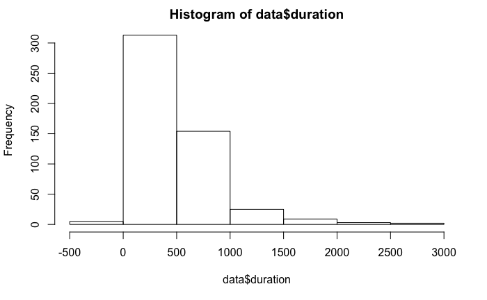

```r
hist(data$duration)
```

```r
# remove respondents with "NA" or any respondents who interrupted the questionnaire (-1)
# this depends highly on the context!
data <- data[!is.na(data$duration),]
data[data[,"duration"] == -1,"duration"] <- NA
table(data[,"duration"] <= 186)
```

```
FALSE  TRUE
  496    10
```

It seems like 10 persons were faster than the recommended cut-off.

```r
data[data[,"duration"] <= 186 & !is.na(data[,"duration"]), "lfdn"]
```

```
 [1] 103 138 173 179 194 294 338 375 479 563
```

```r
data <- data[!(data[,"duration"] <= 186 & !is.na(data[,"duration"])),]
```